# GEP: Evaluation of Groundwater Recharge (Regulation Services) Ecosystem Services

Author

Shunkei Kakimoto

# 1 Introduction

## 1.1 Basic understanding of groundwater recharge as a regulating service

- “Ground-water recharge” broadly describes the replenishment of water to a ground-water flow system (Winter 2000), and **it is a part of the hydrological regulation process** — a key regulating ecosystem service that maintains water flows, mitigates flood and drought risk, and supports other essential services such as water provision, streamflow maintenance, and wetland health.

**Groundwater recharge services supports a range of ecosystem services, including:**

- Water Purification
- Flood and Drought Mitigation
- Soil and Land Stability:
  - Maintaining groundwater levels through recharge helps prevent land subsidence, which can occur when aquifers are depleted. This is crucial for preserving infrastructure and natural landscapes ([EPA](https://www.epa.gov/uic/aquifer-recharge-and-aquifer-storage-and-recovery)).
- Climate Regulation:
  - Groundwater-dependent ecosystems, such as wetlands, play a role in carbon sequestration and climate regulation. Recharge supports these ecosystems by sustaining their water needs.
- Nutrient Cycling:
  - Recharge processes facilitate the movement and transformation of nutrients within the soil and water systems, supporting overall ecosystem productivity and health.

## 1.2 Some Terminologies

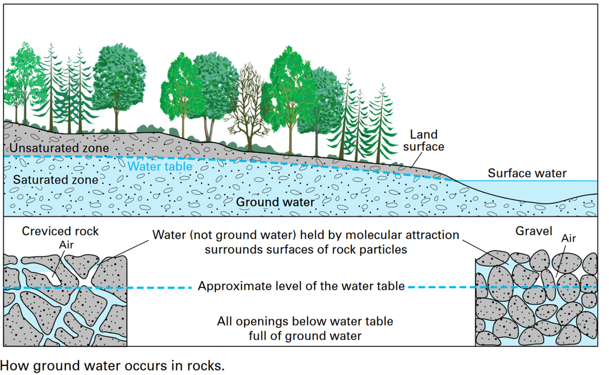

[Source:Groundwater is the saturated zone of soil/rock below the land surface - USGS](https://www.usgs.gov/media/images/groundwater-saturated-zone-soilrock-below-land-surface)

- **Unsaturated zone** is the layer above the saturated zone. Here, the pores contain both air and water. **Water moves through this zone when it rains, trickling down until it reaches the saturated zone. This zone includes soil and sometimes rock, and it’s where plants usually get their water** [[USGS](https://water.usgs.gov/ogw/unsaturated.html#:~:text=The%20unsaturated%20zone%20is%20the,as%20water%20in%20its%20pores.)]
- **Saturated zone** is the part of the ground where **all the pores and spaces between soil or rock particles are completely filled with water. This is where groundwater lives**. If you dig a well deep enough to reach this zone, the water you pump up comes from here. The top of the saturated zone is called the water table. [[USGS](https://water.usgs.gov/ogw/unsaturated.html#:~:text=The%20unsaturated%20zone%20is%20the,as%20water%20in%20its%20pores.)]

**Important**

Hydrologically, **the unsaturated zone** is often the main factor controlling water movement from the land surface to the aquifer. Thus **it strongly affects the rate of aquifer recharge**, critical for the use and management of groundwater. It is often regarded as a filter that removes undesirable substances. To some extent this is true, but **a more general fact is that flow rates and chemical reactions in the unsaturated zone control whether, where, and how fast contaminants enter groundwater supplies**. Understanding of unsaturated-zone processes is therefore crucial in determining the amount and quality of groundwater that is available for human use. - [[USGS](https://water.usgs.gov/ogw/unsaturated.html#:~:text=The%20unsaturated%20zone%20is%20the,as%20water%20in%20its%20pores.)]

## 1.3 Factors Affecting Groundwater Recharge

**1. Groundwater recharge happens in the following two ways**:

- natural part of the hydrologic cycle (e.g., precipitation, snowmelt, surface water infiltration)
- human-induced process (e.g., irrigation and waste disposal, artificial recharge)

**Note**

Our focus in on the groundwater recharge that occurs naturally as part of the hydrologic cycle.

**2. Precipitation is the primary source of groundwater recharge. Multiple factors affects the proportion of precipitation that becomes groundwater recharge, and the time it takes for water to actually move from the surface to the water table.**

- Precipitation is the primary source of groundwater recharge. However, typically, most water from precipitation that infiltrates does not become recharge. Instead, it is stored in the soil zone and eventually returned to the atmosphere by evaporation and plant transpiration (Mehner 2009).
- **A fraction of precipitation that becomes groundwater recharge is highly variable and depends on the multiple factors, including:**
  - Weather patters (e.g., rainfall intensity, duration, and frequency)
    - see Viswanathan (1984) about the recharge characteristics of an unconfined aquifer from the rainfall-water table relationship.
  - Properties of surface soils (e.g., texture, structure, and moisture content)
  - Land cover (e.g., svegetation type)
  - Local topography (e.g., slope)
  - Depth to the water table

**These factors not only vary spatially bit also with respect to time**(Viswanathan 1984).

- **The time it takes for water to actually move from the surface to the surface to the water table is affected by multiple factors:**
  - Soil and rock permeability: Sandy soils allow faster infiltration; clay or rock layers slow it down.
  - Depth to water table: The Ogallala’s water table can be over 100 feet down—water can take decades to get there.
  - Vegetation and land use: Root systems, irrigation return flow, and surface sealing affect infiltration and delay.

**3. Depending on the type of aquifer, the recharge process can be different.**

## 1.4 Annual Groundwater Recharge Rate

- NOTE:An annual groundwater recharge rate means the long-term **average** rate at which precipitation replenishes the groundwater aquifer (Scanlon et al. 2012).
  - For example, if 10 inches of precipitation infiltrates to recharge the aquifer taking 5 years to reach the aquifer, then the annual recharge rate is **10/5 = 2 inches per year**.
- **Ogallala Aquifer (USA)**:
  - Recharge Rate: **0.07 inch per year** were common in much of the area, but as much as **0.8 to 1.0 inch of water per year** might have recharged the aquifer near some streams and between the South Platte and Republican Rivers.
  - Depth to Water Table: 50–300 feet (varies widely)
  - Mostly unconfined
  - Recharge Lag Time: Decades to centuries depending on location
    - [U.S. Geological Survey](https://pubs.usgs.gov/ha/ha730/ch_c/C-text5.html?utm_source=chatgpt.com)
    - [Kansas Geological Survey](https://geohydro.kgs.ku.edu/geohydro/ofr/OFR2007_1/index.html?utm_source=chatgpt.com)
    - Scanlon et al. (2012)
- **Central Valley Aquifer (California, USA)**
  - Recharge Rate: ~0.2 to 5 inches/year, 0.26 to 1.52 inches/year during the 2003-2006 period (P.-W. Liu et al. 2022).
  - Depth to Water Table: 30–200 feet
  - Both confined and unconfined
  - Recharge Lag Time: Years to decades
    - Valley (2009); Bertoldi, Johnston, and Evenson (1991); P.-W. Liu et al. (2022)
    - “USGS Fact Sheet 2009-3057: California’s Central Valley Groundwater Study: A Powerful New Tool to Assess Water Resources in California’s Central Valley” (n.d.)
- **Great Artesian Basin (Australia)**
  - Recharge Rate: ~0.02 to 0.8 inches/year
  - Depth to Water Table: 300 to >3000 feet
  - Mostly confined
  - Recharge Lag Time: Hundreds to thousands of years
    - Ransley et al. (2015)
- **Guarani Aquifer (South America: Brazil, Argentina, Paraguay, Uruguay)**
  - Recharge Rate: 1.2 to 3 inches/year
  - Depth to Water Table: 100–1000 feet
  - Both confined and unconfined; unconfined in recharge areas
  - Recharge Lag Time: Years to decades
    - UNESCO Guarani Aquifer System project ([UNESCO-IHP](https://www.unesco.org/en/water))
- **Alter do Chao Aquifer (Amazon Basin)**
  - Recharge Rate: The aquifer benefits from substantial recharge due to the region’s high annual rainfall, averaging around 2,300 mm (approximately 90 inches) (Tourian, Reager, and Sneeuw 2018)
    - Also, see Henrichs de Azevedo and Guimarães Campos (2021)
  - Depth to Water Table: Miguez-Macho and Fan (2012) shows the water table is generally shallow (less than 2 meters) near valley floors, but can be much deeper (5-40 meters) under higher ground areas of the Amazon basin.
  - Both confined and unconfined conditions, varying by location. In recharge areas where the aquifer material is exposed at the surface, it is typically unconfined, allowing direct infiltration of rainwater. In other regions, it may be confined beneath less permeable layers (Henrichs de Azevedo and Guimarães Campos 2021)
  - Recharge Lag Time: The exact time for surface water to percolate and recharge the aquifer isn’t well-documented. However, the combination of high rainfall and permeable soils suggests that recharge can occur relatively quickly, especially in unconfined sections.
    - Miguez-Macho and Fan (2012)
- **Indo-Gangetic Basin Aquifer (India, Pakistan, Bangladesh)**
  - Recharge Rate: ~4 to 24 inches/year (monsoon-driven)
  - Depth to Water Table: 10–150 feet
  - Mostly unconfined
  - Recharge Lag Time: Days to years
    - MacDonald et al. (2016)
    - NOTE: *Groundwater abstraction from the transboundary Indo-Gangetic Basin comprises 25% of global groundwater withdrawals, sustaining agricultural productivity in Pakistan, India, Nepal and Bangladesh.*
- **North China Plain Aquifer**
  - Recharge Rate: 4 inches/year
  - Depth to Water Table: 100–400 feet (declining due to overuse)
  - Confined/Unconfined: Both; unconfined near recharge zones
  - Recharge Lag Time: Decades
    - Foster and Garduño (2004); Tan et al. (2014);
    - Xiaolin Yang et al. (2015) shows the variation of recharge rates by vegetation types (crop types)
- **Arabian Aquifer System (Saudi Arabia and Gulf countries)**
  - Recharge Rate: <0.1 inch/year (mostly fossil water)
  - Depth to Water Table: 1000–4000 feet
  - Confined/Unconfined: Mostly confined
  - Recharge Lag Time: Hundreds to thousands of years
    - Margat and Gun (2013)

# 2 Previous literature

## 2.1 Review Papers

- **Emerton and Bos (2004)**
  - Ecosystem Valuation Techniques:
    - Market price techniques
    - Effect on production techniques
    - Travel cost techniques
    - Hedonic pricing techniques
    - Replacement cost techniques
      - Estimates the cost of replacing an ecosystem service with a man-made alternative that provides an equivalent function.
    - Mitigative or avertive expenditure techniques
      - Estimates how much people spend to avoid or mitigate the negative effects of the loss or degradation of an ecosystem service.
    - Damage cost techniques
    - Contingent valuation techniques
- Bergkamp and Cross (2006)
- Brauman et al. (2007)

## 2.2 Groundwater Recharge: Hydrological Aspect

## 2.3 **Viswanathan (1984)**

- The study develops a time-series model to estimate how historical rainfall influences water table levels in an unconfined aquifer.
- The novelty of the study is that it used a recursive least-squares algorithm with time-varying parameters, **allowing recharge response to vary over time rather than assuming fixed coefficients.**
- The study found that **time-varying parameters gave better water table predictions than constant-parameter models**, capturing the dynamic infiltration behavior more realistically.
- Furthermore, the study found that recharge is not only a function of rainfall volume but also **its sequence and intensity**. For example, isolated rain events (~25 mm/day)often produce no significant water table rise.

## 2.4 Economic values of groundwater recharge

### 2.4.1 **Barnes et al. (1999)**

- The study evaluate the value of ecosystem services provided by wetlands in the Zambezi River basin system (The largest portion of the basin lies in Zambia).
- They used the **replacement cost approach** to estimate the value of groundwater recharge service provided by wetland for domestic and commercial water use. Specifically, they estimate **what it would cost to provide the same amount of water to users if wetlands no longer recharged the aquifer**
  - They assumed that 35% of the shallow wells would need to be replaced if wetlands became degraded, leading to lower groundwater tables.
- They calculated the NPV of groundwater recharge (US$) as measured by estimating **the additional construction costs and health costs that would be incurred by reduced groundwater recharge due to wetland degradation.**

**Caution**

- They didn’t derive or measure groundwater recharge rate or volumns. In stead, they assumed that 35% of shallow-dug wells would require replacement with boreholes under a scenario of wetland degradation

### 2.4.2 **Acharya and Barbier (2000)**

- They used the **production function approach**,linking increased crop yields from recharge-supported irrigation to ecosystem value of groundwater recharge (for shallow aquifer) in Hadejia-Ngru wetlands in northern Nigeria.
- Groundwater recharge from wetlands supports dry season agriculture through shallow aquifer extraction. Groundwater is the only source for irrigation during the dry season.
- They first calculated **the economic value of agricultural production per hectare of irrigated land** based on the surveyed data.
- Then, they estimate the crop production function (the water-yield relationship) econometrically.
- Using the estimated production function, they **simulated hypothetical reductions in groundwater levels** (which would occur if wetland recharge declined). They then calculated the welfare change (loss in producer surplus) associated with these scenarios. This welfare loss was interpreted as the economic value of the groundwater recharge function provided by the wetlands.

**Caution**

- This study is relevant to the groundwater recharge service for agricultural production.
- They did not directly measure of model the change in the volume of groundwater recharge itself. Instead, they **simulated** the effects of hypothetical changes in groundwater levels.

### 2.4.3 **Campbell, Marks, and Conn (2020)**

**Caution**

- The resulted value of groundwater recharge is not a flow value of groundwater recharge. It is a groundwater recharge “potential” value, which is the maximum economic value of groundwater recharge service that can be obtained if all the amount of groundwater recharge is fully utilized for municipal water supply, recreation, and watershed protection, regardless of the geographic location of the recharge.
  - For example, even if the recharge is located in a remote area, the study assumes that it is fully utilized for municipal water supply, recreation, and watershed protection in the same manner as the recharge located in urban areas.

### 2.4.4 **Rismawati (2024)** (InVest SWY model)

- Rismawati (2024) calculated the economic value of groundwater recharge in the Ciburial spring recharge area (Indonesia) by combining hydrological modeling with a market-based valuation approach.
- An economic valuation was performed on the water provisioning services
- First, she used the **InVEST Seasonal Water Yield model** to estimate the baseflow—representing groundwater recharge—at 32.6 million cubic meters in 2020.
- Then, she estimated **the marginal cost of water production** (according to her explanation) by dividing the total cost of producing spring water (adjusted for inflation) by the volume of water produced, resulting in a unit cost of IDR 946.08 per cubic meter.
  - This is basically a **market price method**.
- Multiplying this price by the recharge volume, she arrived at an economic value of IDR 30.86 billion for the groundwater recharge in 2020.

**Caution**

- Her marginal cost of water approach to estimate the economic value of water supply services is suspicious.

### 2.4.5 **Brauman, Freyberg, and Daily (2015)**

- The study is estimating the cost savings to the local water department from natural groundwater recharge under different land-use scenarios in Kona, Hawaii.
- They first estimated how different land cover types (native forest, plantation forest, pasture) affect groundwater recharge.
- Then, they estimated **changes in groundwater level in response to changes in recharge** by expraporating the results of the groundwater model developed by Oki (1999).
- They estimated the **change in energy costs for water extraction based on the new water table elevation**. A lower water table means more pumping energy is needed, increasing operational costs for the water utility.
- **The difference in pumping costs before and after the land-use change represents the monetary value of the groundwater recharge service, attributed to that land cover scenario.**

**Note**

- **logic**: land-use change → groundwater recharge → change in water table → change in pumping costs
- **The study considers long-term changes in groundwater recharge rates**, acknowledging that factors affecting recharge rates such as precipitation fluctuate year to year. Also, land-use changes takes time to affect recharge rates. > “The paper assumes recharge has a delayed response to land change.”

### 2.4.6 Mitsch and Gosselink (2000)

- They considered the value of groundwater recharge services provided by wetlands, though not in a detailed or monetized form.
  - In Table 2 of their paper, they associate isolated basin wetlands with enhanced values such as “groundwater recharge,” along with flood control and support for amphibians and waterfowl
- Although the paper does not separately quantify or isolate the economic value of groundwater recharge per se, it implies that this function is embedded in broader hydrologic services like flood storage and water quality maintenance—both of which depend on recharge dynamics.

### 2.4.7 Xuyang Yang and Liu (2020) (?)

- They valued the regulating services provided by groundwater—specifically including water conservation and water purification—using proxy methods such as the shadow project approach and replacement cost method.
- For groundwater recharge, which they referred to under “water conservation,” they used the **shadow project approach** by estimating **how much it would cost to replace this service using man-made infrastructure (reservoir costs)**.
- They used the values of reservoir costs from the literature.

### 2.4.8 Qu et al. (2024) (?)

- Almost same as Xuyang Yang and Liu (2020).
- They did not isolate “groundwater recharge” per se as a distinct service but evaluated it indirectly through regulating and supporting services such as:
  - Water conservation: Valued based on groundwater storage (recharge) using an alternative engineering method.
  - Carbon sequestration: Estimated using the cost of afforestation as a proxy, with the total carbon stored in groundwater derived from recharge and discharge processes.

### 2.4.9 Maliva (2014)

- The study derived the economic value of groundwater recharge within the context of Managed Aquifer Recharge (MAR) primarily through cost-benefit analysis (CBA).
- The core idea is to compare the monetary benefits of increased groundwater availability or improved water quality against the costs of implementing MAR systems.

**Note**

> Managed aquifer recharge (MAR) is defined as “intentional banking and treatment of waters in aquifers”. The term MAR was introduced as an alternative to “artificial recharge”, which has the connotation that the use of the water was in some way unnatural.

### 2.4.10 Watanabe and Ortega (2014) (?)

- They developped “hydro-carbon model” that quantifies daily flows of water (including groundwater recharge) and carbon in both mass, emergy (solar equivalent joules), and monetary terms based on emergy-to-dollar conversions.

## 2.5 Previous GEP studies

### 2.5.1 **Ouyang et al. (2020)**

- The study does not provide a standalone estimate for groundwater recharge, nor does it specify the exact price per unit used for this particular service. Rather, **it embeds recharge in the broader accounting of water provisioning, flood regulation**.

### 2.5.2 **Huang et al. (2022)**

- They assess the ecosystem service value (ESV) of paddy field ecosystem (PPE) in Tianjin (the northeast of the North China Plain) using multi-source remote sensing data.
- Groundwater recharge service is accounted for as a part of ecosystem service provided by paddy fields (part of the water in the field seeps into the underground to replenish the groundwater resources).
- They used the **market value method** to calculate the ecological value of groundwater replenishment by assigning economic value based on actual irrigation benefits derived from recharge.

$$\text{The value of GW recharge} = (IW + P_r - ET_{growth}) \times P_{w}$$

, where

- $IW$ is the amount of irrigation water used (mm) during the rice growing season
- $P_r$ is the accumulated precipitation (mm) during the rice growing season (May-Aug)
- $ET_{growth}$ is the cumulative evapotranspiration (mm) in the rice growing season,
- $P_{w}$ is the price of irrigation water (RMB/m3)

### 2.5.4 Zhang, Pang, and Li (2024)

- GEP of 39 wetlands in the middle reaches of the Yellow River in Ningxia province
- Groundwater recharge service is not explicitly evaluated. It is included in the water conservation service, which is evaluated using the market price method.

**GEP_{WC} = A(0.85P - ET) V_{WC}**

where $A$ is the area of the wetland $m^2$, $ET$ is the actual evapotranspiration , $m$, and $V_{WC}$ is the market price for $GEP_{WP}$ comes from the guide (they used some guideline for the price of water in China).

### 2.5.5 Geng and Liang (2021)

- Their study focused entirely on forest ecosystem services in Jiaokou County, Shanxi Province, including water conservation, soil conservation, carbon fixation, oxygen release, atmospheric purification, and biodiversity. Groundwater or aquifer recharge was not mentioned as part of their assessment.

### 2.5.6 Pacetti et al. (2024)

- First European pilot of GEP, applying it to mountainous ecosystems.
- They did not calculate the value of groundwater recharge specifically; they evaluated Groundwater supply – evaluating the use of groundwater resources.

### 2.5.7 Joshi et al. (2025)

- The study estimates the Gross Environment Product (GEP) in Uttarakhand, India.
- They estimate the potential for water recharge through human endeavors (water conservation structures implemented by both the Forest Department and Hal Nigam Uttarakhand) in conjunction with regional rainfall data.
  - A recharge factor, reflecting the proportion of rainfall contributing to aquifer replenishment, was applied to determine the effective volume of water recharged
- Then, Water GEP was computed by integrating the annual Water Quality Index (WQI) with the calculated recharge volumes.

> “**the quantification of water recharged through human endeavors** was undertaken by documenting the cumulative volume of water conservation structures implemented by both the Forest Department and Jal Nigam Uttarakhand. The study considered the volume capacity of these structures in conjunction with regional rainfall data to estimate the potential for water recharge. **A recharge factor, reflecting the proportion of rainfall contributing to aquifer replenishment, was applied to determine the effective volume of water recharged** (Table 7).”

**Caution**

- While groundwater may be indirectly relevant in their “water GEP” category, the paper does not provide a disaggregated or monetary valuation specific to groundwater recharge as a distinct ecosystem service.
- In their study, a recharge factor, which reflects the proportion of rainfall contributing to aquifer replenishment, is not clearly defined. They assumed a recharge factor of 0.5.

## 2.6 Overall Comments on the previous studies evaluating the economic value of groundwater recharge.

**Note**

Rismawati (2024) used the InVEST Seasonal Water Yield model to estimate the volume of groundwater recharge.

# 3 Calculation of GEP of groundwater recharge

## 3.1 Research Question

Most existing studies estimate the value of groundwater recharge primarily as a provisioning service, focusing on its contribution to current water supply.

- However, this perspective may overstate its short-term importance, as annual recharge volumes are typically small compared to the total stock of groundwater stored in aquifers. Thus, the water provisioning service of groundwater is likely rely heavily on the existing groundwater stock not on the annual recharge.

In this study, I instead evaluate groundwater recharge as a regulating service, emphasizing **its role in sustaining aquifer levels**. From a human welfare perspective, this regulatory function is essential because it helps slow the long-term decline of groundwater tables, thereby **avoiding increased pumping costs and the need for infrastructure adaptation** (e.g., deeper wells, more energy-intensive extraction). To quantify this service, I pose the following research question:

- **“If the recharge didn’t happen, what would it cost to deliver the same amount of water to people or systems that currently benefit from it?”**
  - For example, water table would decrease in the absence of groundwater recharge. This would lead to the following two consequences (Acharya and Barbier 2000):
    - 1. As groundwater falls below a certain level, the costs of pumping water are likely to rise.
    - 2. if groundwater levels fall below the maximum depth of the well, the well will no longer be able to supply water, thereby it causes economic losses to the users (people have to give up any revenue they would have received from the water supply, or people have to drill new wells to access the water).

This framing aligns with the logic of the replacement cost approach. The change in pumping costs associated with the change in groundwater levels due to groundwater recharge has been used as a measure of the value of groundwater recharge in the literature (e.g., Acharya and Barbier (2000), Brauman, Freyberg, and Daily (2015)). This allows for estimating the gross ecosystem product (GEP) of recharge based on the costs that would be incurred to replicate its function artificially or offset the consequences of its absence.

### 3.1.1 Final Remark

**In the previous studies, it is often assumed that precipitation in a given year that is infilterd into the soil is the amount of groundwater recharge in that year.**

- While this assumption is valid for some regions (e.g., shallow aquifers), it does not hold true for all regions. Water recharge is a slow process that can take long time. Thus, **the annual recharge volume is not equal to the amount of groundwater recharge in that year**. Past precipitation events can contribute to current recharge. Therefore, omitting this lag time can lead to an underestimation of the value of groundwater recharge in a specific year.

## 3.2 Approach: Conceptural Framework

**I will conduct the analysis on a watershed scale.**

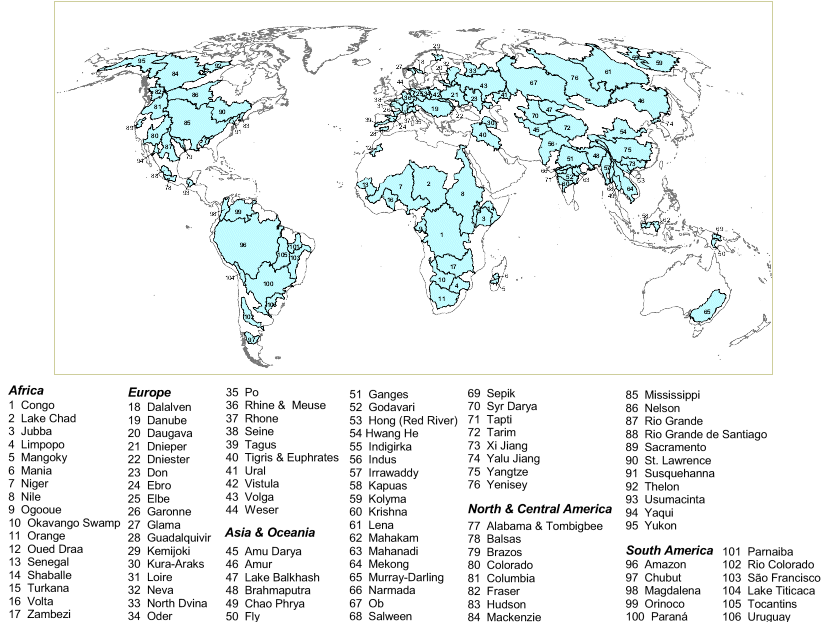

106 major watersheds of the world - [UN ATLAS OF THE OCEANS](https://www.oceansatlas.org/subtopic/en/c/593/)

1. **Estimate the volume of natural groundwater recharge per year for each watershed $i$, $\Delta Q_i$ ($inches$) with the local recharge output (i.e., the amount of rainfall that infiltrates into soil, minus what is evaporated or used by vegetation) from InVEST Seasonal Water Yield (SWY) model under some assumptions.**
2. **Estimate the marginal cost of pumping water from the aquifer to the surface (e.g., the cost of electricity) as a function of the depth of the water table:**
- I need to assume functional form of the cost function (for example, see Acharya and Barbier (2000)).

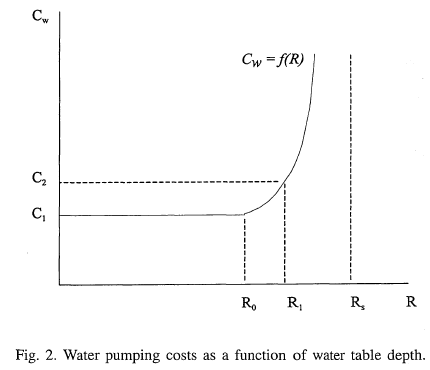

In other words, I interpret the value as the benefit of groundwater recharge to maintain the water table at a certain level, which save the pumping costs for the society.

## 3.3 Methodology and Data

### 3.3.1 Estimation of Groundwater Recharge

- **InVEST Seasonal Water Yield (SWY) model** ([here](https://naturalcapitalproject.stanford.edu/invest/seasonal-water-yield)) to estimate the “potential” groundwater recharge at the watershed scale.
- The outputs of the SWY model are quickflow, **local recharge**, and baseflow. Specifically, **local recharge (i.e., the amount of rainfall that infiltrates into soil, minus what is evaporated or used by vegetation)** is the most relevant output for estimating groundwater recharge.

**Warning**

I need to be careful about the use of local recharge output to estimate groundwater recharge in a specific year. + Although local recharge represents infiltration below the root zone, which may eventually reach the aquifer, **not all of it necessarily becomes recharge depending on local geology, depth to water table, and permeability**. + So, it should be regarded as a potential groundwater recharge estimate, or upper-bound estimate of groundwater recharge.

- So, **the SWY model does not simulate deep percolation or aquifer dynamics. It only estimates potential recharge, not actual recharge reaching saturated zones.**
- It might be more realistic to assume that the volume of grondwater recharge at a specific year is contributed by the historical precipitation over the past years (e.g., past 5 years).
  - step 1: Derive the historical water flows that reaches the watershed from precipitation.
  - step 2: Derive the volume of water that infiltrates into the soil and reaches the aquifer in that specific year by those historical water flows (use some weighting factors?).

### 3.3.2 Assumptions

- **I need to assume that some fixed proportion of the local recharge (e.g., 50%) becomes groundwater recharge**.
  - This is because the local recharge is not equal to the groundwater recharge. Some portion of the local recharge will be soaked up by the soil and vegetation.
  - For example, I might be able to approximate the proportion of local recharge that becomes groundwater recharge by comparing the local recharge value from the SWY model with the actual groundwater recharge rate in the past.
  - For example, if the estimated local recharge is 100 mm and the actual groundwater recharge rate is 50 mm in a specific year for a given watershed, then I can assume that 50% of the local recharge becomes groundwater recharge for that watershed.
- In addition to the fixed proportion of local recharge, I need to assume that only a portion of local recharge that enters **the aquifer recharge areas** are potentially available for groundwater recharge.
  - Kallali et al. (2007)
  - Identifying Optimal Groundwater Recharge Locations
- Also, **I need to assume that the water is immediately recharged groundwater.** In other words, it should not take long time (years) to recharge the aquifer.
- Following Brauman, Freyberg, and Daily (2015), it is assumed that **a linear relationship between fractional recharge and absolute water table change.**

### 3.3.3 Data requirements for the SWY model

- DEM
- Precipitation
- Evapotranspiration
- Soil information
- Land use land cover
- Rain Events Table
- Biophysical table

## 3.4 Pumping Cost Function

- Pumping costs for irrigation are well understood from engineering research, and can be accurately predicted for most irrigation systems (Williams et al. (1996)).
  - Several economic studies related to groundwater management literature relied on the engineering formulas to estimate the irrigation pumping costs.
- The level of goundwater table can be inferred from **Gravity Recovery and Climate Experiment (GRACE) Satellite Data** ([Here](https://sealevel.nasa.gov/missions/grace))
  - GRACE doesn’t directly measure recharge, but detects **changes in total water storage (TWS)**.
  - Not direct recharge estimates, and coarse resolution (typically >100,000 km²).
  - This datasets are used by Eicker et al. (2016), Scanlon et al. (2018), Tapley et al. (2019), P.-W. Liu et al. (2022), for example.

## 3.5 Expected Results

- I expect that the cost is not that large, because volume (stock) of available groundwater would be still large even if we missed the amount of groundwater recharge for a single year. Thus, groundwater recharge may seem to have **minimal immediate economic value**.
- I expect that the economic values of groundwater recharge have spatial and temporal variation.

## 3.6 Other Models and Datasets

### 3.6.1 Simulation Model

**WGHM (WaterGAP Global Hydrological Model)**

> WaterGAP Global Hydrological Model computes calculates time series of surface and subsurface runoff, groundwater recharge, and river flows along with water storage variations in canopy, snow, soil, groundwater, rivers, lakes, and wetlands.” (Masood et al., 2022)
- Read Sanford (2002)
- Read Doble and Crosbie (2017)

### 3.6.2 Datasets

**Groundwater recharge rate for the US**

- **The USGS National Hydrography Database (NHD) spatial assessment of groundwater recharge** ([Here](https://www.usgs.gov/national-hydrography/nhdplus-high-resolution))
- This dataset was used by (Campbell, Marks, and Conn 2020). They used the “Estimated Mean Annual Natural Groundwater Recharge, 2002” for the mid-Atlantic region. This layer was specifically created to estimate the mean annual natural groundwater recharge, in millimeters, per watershed catchment segment in the application of the national SPAtially Referenced Regression On Watershed attributes (SPARROW) model.

## 3.7 Cautions:

### 3.7.1 **Recharge maintains long-term viability—not just immediate supply**

Even if there’s “plenty of water” in a given year, **ongoing recharge slows depletion**. Without it, aquifers could face:

- **Progressive decline of the water table**, increasing energy costs over time,
- **Reduced yields from existing wells**, requiring deeper drilling or new infrastructure,
- **Drying of shallow wells** (especially critical in rural and poor communities),
- **Saltwater intrusion** in coastal aquifers (e.g., parts of Mozambique or Bangladesh),
- **Land subsidence** in extreme depletion zones (e.g., Central Valley, California). Recharge doesn’t necessarily prevent collapse immediately, but it **buffers and delays** these outcomes.

**Note**

But GEP is focused on the **value of ecosystem service flows actually delivered within that year**—not potential future losses. So, this is not relevant.

### 3.7.2 **Recharge supports more than just human extraction**

In many areas, groundwater discharge sustains **wetlands, springs, river baseflows**, and **ecosystem functions** that are **valuable to humans**. Without recharge:

- **Spring-fed water bodies** may dry,
- **Riparian habitats** degrade,
- **Biodiversity, tourism, and water quality benefits** can be lost.

So even if people can still pump water, **the wider welfare effects** (e.g., to agriculture, fisheries, or cultural services) may be **non-negligible**.

**Note**

But this depends heavily on the local hydrology and ecosystem use patterns. It is highly challenging to account for context-specific values of these services.

### 3.7.3 InVEST SWY model limitations

- The InVEST Seasonal Water Yield (SWY) model does not directly simulate groundwater recharge, nor does it account for lagged effects from past years’ precipitation. It provides an estimate of how much water runs off or percolates past the root zone, but it does not track soil moisture or subsrface flow across years.
- It assumes a one-year water balance. In other words, all recharge is assumed to occure (or not) within the year of simulation.
- It does not incorporate memory or carryover effects from prior years’ precipitation.
- **In summary, it might not be suitable for modeling aquifer recharge explicitly.**

# 4 Groundwater Rechage Models

**My Goal:**

I am instrested in:

- Estimating groundwater recharge
- and captureing multi-year precipitation effects on recharge.

**Key Words:**

**“memory effects”** + For example, see Section 4.1 Auto- and cross-correlations in Cai and Ofterdinger (2016). + Also, see Mangin (1984)

## 4.1 Previous Studies: Memory Effects on Groundwater Recharge

### 4.1.1 **Hu et al. (2025)**

- western Mongolian Plateau
- examine the dynamics of groundwater leakage and its implications for terrestrial water storage (TWS) and groundwater stability from 2002 to 2022.
- Analyzes how warm-season precipitation variability controls groundwater recharge in permafrost-affected basins.

### 4.1.2 **Oluwaniyi et al. (2023)**

- Used GRACE satellite data and the Water Table Fluctuation (WTF) method.
- Found a 1–2 year lag between precipitation changes and groundwater storage response.
- The study highlights the potential cumulative influence of multi-year climatic conditions on groundwater recharge trends, suggesting a complex relationship that goes beyond just the direct influence of precipitation.

**Substantial temporal memory impact**

They found that the groundwater system exhibits a strong temporal dependence, where the current and future states are highly correlated with past states. This long-term memory or persistence in the system’s behavior challenges the assumption of stationary dynamics and suggests that the temporal component plays a significant role in the groundwater storage dynamics.

### 4.1.3 **Q. Liu et al. (2023)**

- Employed stepwise state modeling across global watersheds.
- Demonstrated lagged and amplified streamflow responses due to prolonged drought.
- Recharge patterns altered after ~7 years of drought, highlighting **deep system memory**.

### 4.1.4 **Schreiner-McGraw and Ajami (2021)**

- Combined hydrological modeling and observational datasets in ungauged basins.
- **Found 2–5 year lags in recharge in dry climates.**
- **Recharge delay increased under drought without anthropogenic management.**

### 4.1.5 **Z. Liu et al. (2025)**

- Used wavelet analysis on soil moisture and precipitation data.
- Quantified monthly-to-yearly lags in precipitation-recharge relationship.
- Emphasized seasonality and antecedent moisture conditions.

**Interesting Findings**

*… a change in the mechanism of precipitation recharge to groundwater, which is likely closely related to intensified human activities, changes in the irrigation water extraction methods, and over-extraction of groundwater.*

### 4.1.6 **Cai and Ofterdinger (2016)** Important

**Important**

Highlights: + Direct groundwater recharge to shallow or deep bedrocks on hillslope is very limited. + Direct recharge takes place within the subsoil and soil/bedrock interface. + Low intensity rainfall events (<=1 mm/h) have higher impact on recharge rate. + Recharge rates of 42–197 mm/yr were estimated.

### 4.1.8 **Sun et al. (2024)** Important

- *The water tbale fluctuation (WTF) method is popular fo groundwater recharge (GR) estimation, but its accuracy is challenged when applied in arreas with thick vadose zones because of the signal lag and attenuation with depth and uncertainties from barometric pressure effect and lateral flow.*
- Proposed a improved method for estimating groundwater recharge using a combination of the linear regression method and Darcy’s law.
  - Integrated water table fluctuation data and vegetation indices.
- Lags ranged from 1 to 9 months, modulated by evapotranspiration and land cover.
- Proposed methodological improvement for thick vadose zones.

### 4.1.9 **Wolf et al. (2023)** Important

- Studied snow-dominated mountainous catchments using multi-year lag regression models.
- Recharge depended not just on current snowmelt but on prior 2–3 years’ precipitation.
- Suggested snow legacy effects play a crucial role.

**Findings:**

*More broadly, these results highlight the importance of including the influence of antecedent climate on groundwater storage when modeling and managing water supplies from seasonally snow-covered catchments.*

### 4.1.10 **Rossman et al. (2014)**, Nebraska

- Modeled climate-driven recharge lag in semi-arid regions.
- Identified vadose zone as buffering and delaying recharge by 6–18 months.

### 4.1.11 **Meter and Basu (2015)**

- Introduced legacy storage modeling with parsimonious watershed model.
- Though focused on nutrients, emphasized how storage buffers and delays recharge signals over multi-decadal timescales.

## 4.2 Literature Review: Process-based Modeling of Groundwater Recharge

### 4.2.1 **Chandra and Sahoo (2024)**: SWAT model

Recharge: Not the primary output but included in the water balance components modeled.

- **Data Layers Provided**:
  - Global Soil Maps: Harmonized World Soil Database (HWSD)
  - Land Use Maps: GlobCover, CORINE, and others.
  - Climate Data: Historical (CRU, ERA), and projected climate (CMIP5).
  - Evapotranspiration: MODIS-based actual evapotranspiration (AET)
- **Utility**:
  - Datasets formatted to plug directly into SWAT/SWAT+ and SWAT-CUP workflows.
  - Supports continental and global hydrological modeling, including water balance components such as groundwater recharge.
- **Key Contributions**:
  - Enables global-scale hydrological simulations with consistent data structure.
  - Aims to reduce data preparation bottlenecks in large-scale modeling.
  - Supports both current condition and climate change scenario modeling.

## 4.3 Model Overview: Process Modeling

- USGS Soil-Water-Balance (SWB) model.
- Stephen, Nielsen, and Ladd (2021)
- SWAT+ (updated SWAT for better process control)
- MIKE SHE (for more detailed coupled modeling)
- WALRUS (for shallow aquifer contexts)

# 5 Datasets

- 235 major water basins, “dlineated using a combination of catchment and geopolitical boundaries” (Turner et al. 2019)
- Evapotranspiration (ET) data:
  - See Hu et al. (2025)

## References

Acharya, Gayatri, and Edward B. Barbier. 2000. “Valuing Groundwater Recharge Through Agricultural Production in the Hadejia-Nguru Wetlands in Northern Nigeria.” *Agricultural Economics* 22 (3): 247–59. https://doi.org/10.1111/j.1574-0862.2000.tb00073.x.

Barnes, Jonathan, L. (Lucy) Emerton, Brad Smith, and Jane Turpie. 1999. *Economic Value of the Zambezi Basin Wetlands*. IUCN.

Bergkamp, Ger, and Katharine Cross. 2006. “Groundwater and Ecosystem Services: Towards Their Sustainable Use.” In *Proceedings of the International Symposium on Groundwater Sustainability*, 177–93. Spain: InterAcademy Panel Alicante.

Bertoldi, G. L., Richard H. Johnston, and Kristin D. Evenson. 1991. *Ground Water in the Central Valley, California: A Summary Report*. U.S. Government Printing Office.

Brauman, Kate A., Gretchen C. Daily, T. Ka’eo Duarte, and Harold A. Mooney. 2007. “The Nature and Value of Ecosystem Services: An Overview Highlighting Hydrologic Services.” *Annual Review of Environment and Resources* 32 (Volume 32, 2007): 67–98. https://doi.org/10.1146/annurev.energy.32.031306.102758.

Brauman, Kate A., David L. Freyberg, and Gretchen C. Daily. 2015. “Impacts of Land-Use Change on Groundwater Supply: Ecosystem Services Assessment in Kona, Hawaii.” *Journal of Water Resources Planning and Management* 141 (12): A4014001. https://doi.org/10.1061/(ASCE)WR.1943-5452.0000495.

Cai, Zuansi, and Ulrich Ofterdinger. 2016. “Analysis of Groundwater-Level Response to Rainfall and Estimation of Annual Recharge in Fractured Hard Rock Aquifers, NW Ireland.” *Journal of Hydrology* 535 (April): 71–84. https://doi.org/10.1016/j.jhydrol.2016.01.066.

Campbell, Elliott, Rachel Marks, and Christine Conn. 2020. “Spatial Modeling of the Biophysical and Economic Values of Ecosystem Services in Maryland, USA.” *Ecosystem Services* 43 (June): 101093. https://doi.org/10.1016/j.ecoser.2020.101093.

Chandra, Nathi Ajay, and Sanat Nalini Sahoo. 2024. “Assessing the Impacts of Climate and Land Cover Change on Groundwater Recharge in a Semi-Arid Region of Southern India.” *Theoretical and Applied Climatology* 155 (8): 7147–63. https://doi.org/10.1007/s00704-024-05065-8.

Deng, Haoyu, Chengmin Li, Tong Chen, Yulan Song, and Jian Cao. 2025. “Valuing the Ecological Products of Wetlands and Strategies for Implementation: A Case Study of Weishui Wetland in Songzi City, Hubei Province.” *Polish Journal of Environmental Studies* 34 (3): 2627–45.

Doble, Rebecca C., and Russell S. Crosbie. 2017. “Review: Current and Emerging Methods for Catchment-Scale Modelling of Recharge and Evapotranspiration from Shallow Groundwater.” *Hydrogeology Journal* 25 (1): 3–23. https://doi.org/10.1007/s10040-016-1470-3.

Eicker, Annette, Ehsan Forootan, Anne Springer, Laurent Longuevergne, and Jürgen Kusche. 2016. “Does GRACE See the Terrestrial Water Cycle ‘Intensifying’?” *3* 121 (2): 733–45. https://doi.org/10.1002/2015JD023808.

Emerton, Lucy, and Elroy Bos. 2004. *Value: Counting Ecosystems as Water Infrastructure*. IUCN.

Foster, Stephen, and Héctor Garduño. 2004. “China: Towards Sustainable Groundwater Resource Use for Irrigated Agriculture on the North China Plain.” *Sustainable Groundwater Management, Lessons from Practice, Case Profile Collection* 8: 4602122–1210186345144.

Geng, Jianxin, and Chengzhi Liang. 2021. “Analysis of the Internal Relationship Between Ecological Value and Economic Value Based on the Forest Resources in China.” *Sustainability* 13 (12): 6795. https://doi.org/10.3390/su13126795.

Henrichs de Azevedo, Júlio, and José Eloi Guimarães Campos. 2021. “Flow Patterns and Aquifer Recharge Controls Under Amazon Rainforest Influence: The Case of the Alter Do Chão Aquifer System.” *Journal of South American Earth Sciences* 112 (December): 103596. https://doi.org/10.1016/j.jsames.2021.103596.

Hu, Shun, Cenhanyi Hu, Keyu Meng, Yinghui Long, Jing Zhang, Mingxin Wang, Linglin Zeng, and Zilong Liao. 2025. “Groundwater Leakage of an Endorheic Basin with Extensive Permafrost Coverage in the Western Mongolian Plateau.” *Journal of Hydrology* 657 (August): 133175. https://doi.org/10.1016/j.jhydrol.2025.133175.

Huang, Tiecheng, Wenjiang Huang, Kun Wang, Yongkang Li, Zhenhai Li, and Yong’an Yang. 2022. “Ecosystem Service Value Estimation of Paddy Field Ecosystems Based on Multi-Source Remote Sensing Data.” *Sustainability* 14 (15): 9466. https://doi.org/10.3390/su14159466.

Joshi, Anil Prakash, Shivam Joshi, Ramesh Kumar Sudhanshu, Durgesh Pant, Sushil Rai, Atul Rawat, and Himani Purohit. 2025. “Deciphering Uttarakhand’s Human Efforts Towards the Ecology Through Gross Environment Product (GEP) Calculations.” *Environmental and Sustainability Indicators* 25: 100578.

Kallali, Hamadi, Makram Anane, Salah Jellali, and Jamila Tarhouni. 2007. “GIS-based Multi-Criteria Analysis for Potential Wastewater Aquifer Recharge Sites.” *Desalination*, MEDAWATER International Conference on Sustainable Water Management, Rational Water Use, Wastewater Treatment and Reuse, 215 (1): 111–19. https://doi.org/10.1016/j.desal.2006.11.016.

Liu, Pang-Wei, James S. Famiglietti, Adam J. Purdy, Kyra H. Adams, Avery L. McEvoy, John T. Reager, Rajat Bindlish, David N. Wiese, Cédric H. David, and Matthew Rodell. 2022. “Groundwater Depletion in California’s Central Valley Accelerates During Megadrought.” *Nature Communications* 13 (1): 7825. https://doi.org/10.1038/s41467-022-35582-x.

Liu, Qiang, Yuting Yang, Liqiao Liang, Denghua Yan, Xuan Wang, Chunhui Li, and Tao Sun. 2023. “Shift in Precipitation-Streamflow Relationship Induced by Multi-Year Drought Across Global Catchments.” *Science of The Total Environment* 857 (January): 159560. https://doi.org/10.1016/j.scitotenv.2022.159560.

Liu, Zhongpei, Xiaoqing Li, Zhipeng Hu, Runxiang Cao, Yuping Han, and Lin Wu. 2025. “Time Lag Effect of Precipitation on Groundwater Level Based on Wavelet Analysis in the People’s Victory Canal Irrigation Area, China.” *Scientific Reports* 15 (1): 12130. https://doi.org/10.1038/s41598-025-96644-w.

MacDonald, A. M., H. C. Bonsor, K. M. Ahmed, W. G. Burgess, M. Basharat, R. C. Calow, A. Dixit, et al. 2016. “Groundwater Quality and Depletion in the Indo-Gangetic Basin Mapped from in Situ Observations.” *Nature Geoscience* 9 (10): 762–66. https://doi.org/10.1038/ngeo2791.

Maliva, Robert G. 2014. “Economics of Managed Aquifer Recharge.” *Water* 6 (5): 1257–79. https://doi.org/10.3390/w6051257.

Mangin, Alain. 1984. “The Use of Autocorrelation and Spectral Analyses to Obtain a Better Understanding of Hydrological Systems(Pour Une Meilleure Connaissance Des Systemes Hydrologiques a Partir Des Analyses Corelatoire Et Spectrale).” *Journal of Hydrology* 67 (1): 25–43. https://doi.org/10.1016/0022-1694(84)90230-0.

Margat, Jean, and Jac van der Gun. 2013. *Groundwater Around the World: A Geographic Synopsis*. CRC Press.

Mehner, Thomas. 2009. *Encyclopedia of Inland Waters*. Academic Press.

Meter, Kimberly J. Van, and Nandita B. Basu. 2015. “Catchment Legacies and Time Lags: A Parsimonious Watershed Model to Predict the Effects of Legacy Storage on Nitrogen Export.” *PLOS ONE* 10 (5): e0125971. https://doi.org/10.1371/journal.pone.0125971.

Miguez-Macho, Gonzalo, and Ying Fan. 2012. “The Role of Groundwater in the Amazon Water Cycle: 2. Influence on Seasonal Soil Moisture and Evapotranspiration.” *Journal of Geophysical Research: Atmospheres* 117 (D15). https://doi.org/10.1029/2012JD017540.

Mitsch, William J., and James G. Gosselink. 2000. “The Value of Wetlands: Importance of Scale and Landscape Setting.” *Ecological Economics* 35 (1): 25–33. https://doi.org/10.1016/S0921-8009(00)00165-8.

Oki, Delwyn S. 1999. *Geohydrology and Numerical Simulation of the Ground-water Flow System of Kona, Island of Hawaii*. U.S. Department of the Interior, U.S. Geological Survey.

Oluwaniyi, Olaoluwa, Yong Zhang, Hossein Gholizadeh, Bailing Li, Xiufen Gu, HongGuang Sun, and Chengpeng Lu. 2023. “Correlating Groundwater Storage Change and Precipitation in Alabama, United States from 2000–2021 by Combining the Water Table Fluctuation Method and Statistical Analyses.” *Sustainability* 15 (21): 15324. https://doi.org/10.3390/su152115324.

Ouyang, Zhiyun, Changsu Song, Hua Zheng, Stephen Polasky, Yi Xiao, Ian J. Bateman, Jianguo Liu, et al. 2020. “Using Gross Ecosystem Product (GEP) to Value Nature in Decision Making.” *Proceedings of the National Academy of Sciences* 117 (25): 14593–601. https://doi.org/10.1073/pnas.1911439117.

Pacetti, Tommaso, Marco Lompi, Giovanna Panza, Alessandro Bosso, Marco Monaci, Giovanni Pasini, and Riccardo Santolini. 2024. “Gross Ecosystem Product as a Measure of Natural Capital Value: An Italian Experience.” *Earth Systems and Environment*, October. https://doi.org/10.1007/s41748-024-00492-z.

Qu, Jihong, Jueyan Jiang, Tiangang Yan, Yuepeng Li, Ran Tian, and Liuyue Wang. 2024. “Evolution of Groundwater Ecosystem Service Value in the Receiving Areas of Beijing-Tianjin-Hebei Around the Opening of the Middle Route Project of South-to-North Water Diversion.” *Acta Geophysica* 72 (4): 2743–58. https://doi.org/10.1007/s11600-023-01191-5.

Ransley, T, BM Radke, H Carey, Gerard Stewart, J Bell, R Owens, James Ronald Kellett, and Andrew J Feitz. 2015. *Hydrogeological Atlas of the Great Artesian Basin*. Geoscience Australia.

Rismawati, W. 2024. “Economic Valuation of Water Provisioning Services in the Recharge Area of Ciburial Spring, Bogor Regency.” https://doi.org/10.22004/ag.econ.344445.

Rossman, N. R., V. A. Zlotnik, C. M. Rowe, and J. Szilagyi. 2014. “Vadose Zone Lag Time and Potential 21st Century Climate Change Effects on Spatially Distributed Groundwater Recharge in the Semi-Arid Nebraska Sand Hills.” *Journal of Hydrology* 519 (November): 656–69. https://doi.org/10.1016/j.jhydrol.2014.07.057.

Sanford, Ward. 2002. “Recharge and Groundwater Models: An Overview.” *Hydrogeology Journal* 10 (1): 110–20. https://doi.org/10.1007/s10040-001-0173-5.

Scanlon, Bridget R., Claudia C. Faunt, Laurent Longuevergne, Robert C. Reedy, William M. Alley, Virginia L. McGuire, and Peter B. McMahon. 2012. “Groundwater Depletion and Sustainability of Irrigation in the US High Plains and Central Valley.” *Proceedings of the National Academy of Sciences* 109 (24): 9320–25. https://doi.org/10.1073/pnas.1200311109.

Scanlon, Bridget R., Zizhan Zhang, Himanshu Save, Alexander Y. Sun, Hannes Müller Schmied, Ludovicus P. H. van Beek, David N. Wiese, et al. 2018. “Global Models Underestimate Large Decadal Declining and Rising Water Storage Trends Relative to GRACE Satellite Data.” *Proceedings of the National Academy of Sciences* 115 (6): E1080–89. https://doi.org/10.1073/pnas.1704665115.

Schreiner-McGraw, Adam P., and Hoori Ajami. 2021. “Delayed Response of Groundwater to Multi-Year Meteorological Droughts in the Absence of Anthropogenic Management.” *Journal of Hydrology* 603 (December): 126917. https://doi.org/10.1016/j.jhydrol.2021.126917.

Stephen, M. Westenbroek, Martha G. Nielsen, and David E. Ladd. 2021. “Initial Estimates of Net Infiltration and Irrigation from a Soil-Water-Balance Model of the Mississippi Embayment Regional Aquifer Study Area.” 2021-1008. *Open-File Report*. U.S. Geological Survey. https://doi.org/10.3133/ofr20211008.

Sun, Jineng, Yan, Li, Wang, Liu, and Zhi and Li. 2024. “Improving the Water Table Fluctuation Method to Estimate Groundwater Recharge Below Thick Vadose Zones.” *Hydrological Sciences Journal* 69 (14): 2044–56. https://doi.org/10.1080/02626667.2024.2400208.

Tan, Xiu-Cui, Jing-Wei Wu, Shu-Ying Cai, and Jin-Zhong Yang. 2014. “Characteristics of Groundwater Recharge on the North China Plain.” *Groundwater* 52 (5): 798–807. https://doi.org/10.1111/gwat.12114.

Tapley, Byron D., Michael M. Watkins, Frank Flechtner, Christoph Reigber, Srinivas Bettadpur, Matthew Rodell, Ingo Sasgen, et al. 2019. “Contributions of GRACE to Understanding Climate Change.” *Nature Climate Change* 9 (5): 358–69. https://doi.org/10.1038/s41558-019-0456-2.

Tourian, M. J., J. T. Reager, and N. Sneeuw. 2018. “The Total Drainable Water Storage of the Amazon River Basin: A First Estimate Using GRACE.” *Water Resources Research* 54 (5): 3290–3312. https://doi.org/10.1029/2017WR021674.

Turner, Sean W. D., Mohamad Hejazi, Catherine Yonkofski, Son H. Kim, and Page Kyle. 2019. “Influence of Groundwater Extraction Costs and Resource Depletion Limits on Simulated Global Nonrenewable Water Withdrawals Over the Twenty-First Century.” *Earth’s Future* 7 (2): 123–35. https://doi.org/10.1029/2018EF001105.

“USGS Fact Sheet 2009-3057: California’s Central Valley Groundwater Study: A Powerful New Tool to Assess Water Resources in California’s Central Valley.” n.d. https://pubs.usgs.gov/fs/2009/3057/. Accessed April 14, 2025.

Valley, Sacramento. 2009. “Groundwater Availability of the Central Valley Aquifer, California.” *US Geological Survey Professional Paper*.

Viswanathan, MN. 1984. “Recharge Characteristics of an Unconfined Aquifer from the Rainfall-Water Table Relationship.” *Journal of Hydrology* 70 (1-4): 233–50.

Watanabe, Marcos D. B., and Enrique Ortega. 2014. “Dynamic Emergy Accounting of Water and Carbon Ecosystem Services: A Model to Simulate the Impacts of Land-Use Change.” *Ecological Modelling*, Environmental Accounting: Emergy, Systems Ecology and Ecological Modelling, 271 (January): 113–31. https://doi.org/10.1016/j.ecolmodel.2013.03.006.

Williams, Jeffery R., Richard V. Llewelyn, Dan DeLano, and Ilango Thangavelu. 1996. “Irrigation Cost Estimation Procedures Used in the Irrigation Economics Evaluation System (lEES).” https://doi.org/10.22004/ag.econ.133793.

Winter, Thomas C. 2000. *Ground Water and Surface Water: A Single Resource*. DIANE Publishing.

Wolf, Margaret A., Logan R. Jamison, D. Kip Solomon, Courtenay Strong, and Paul D. Brooks. 2023. “Multi-Year Controls on Groundwater Storage in Seasonally Snow-Covered Headwater Catchments.” *Water Resources Research* 59 (6): e2022WR033394. https://doi.org/10.1029/2022WR033394.

Yang, Xiaolin, Yuanquan Chen, Steven Pacenka, Wangsheng Gao, Min Zhang, Peng Sui, and Tammo S. Steenhuis. 2015. “Recharge and Groundwater Use in the North China Plain for Six Irrigated Crops for an Eleven Year Period.” *PLOS ONE* 10 (1): e0115269. https://doi.org/10.1371/journal.pone.0115269.

Yang, Xuyang, and Jian Liu. 2020. “Assessment and Valuation of Groundwater Ecosystem Services: A Case Study of Handan City, China.” *Water* 12 (5): 1455. https://doi.org/10.3390/w12051455.

Zhang, Bi, Aiping Pang, and Chunhui Li. 2024. “Spatial–Temporal Patterns and the Driving Mechanism for the Gross Ecosystem Product of Wetlands in the Middle Reaches of the Yellow River.” *Water* 16 (22): 3302. https://doi.org/10.3390/w16223302.